# GEOG 6000 Lab Plotting with ggplot2

We might be interested in looking at the histogram of values by continent. There are a couple of ways to do this. The first is to include an aesthetic which links the continent to the color used to fill the histograms. Note that we do this by adding the aesthetic to the `geom_*` function (you could equally remake the original `ggplot()` command with this included):

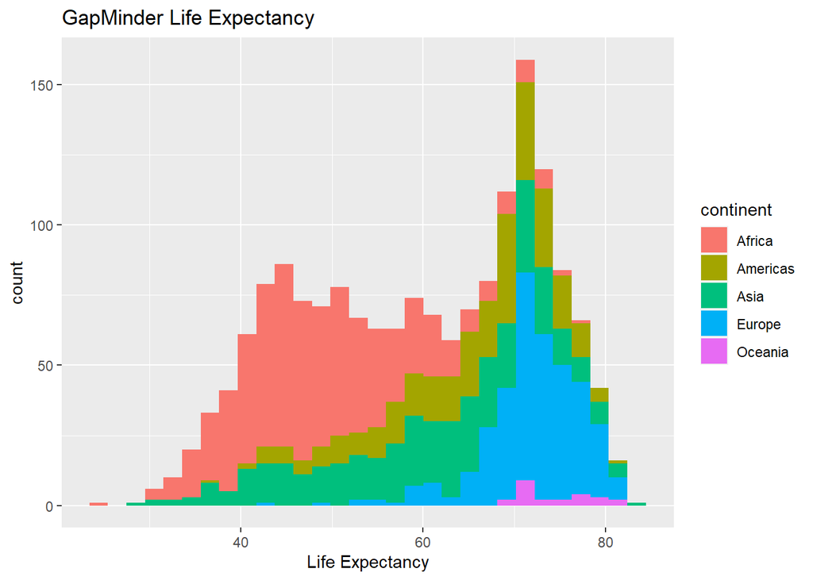

```r
myplot + geom_histogram(aes(fill = continent))
```

By default, `ggplot` stacks the histograms - a better way to do this is have all bars starting at zero and superimposed. This can be achieved with the `position` parameter:

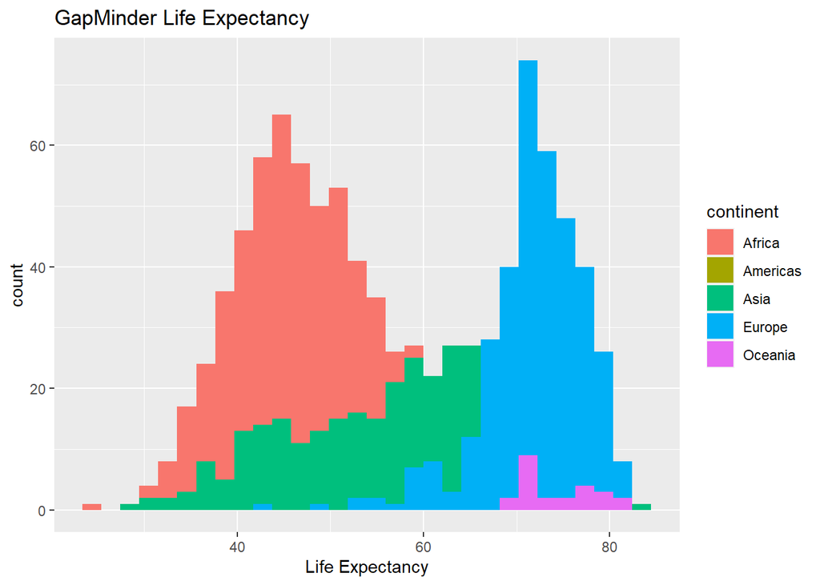

```r
myplot + geom_histogram(aes(fill = continent), position = "identity")
```

An alternative display with several groups is to use *facets*. There are two types of facets in **ggplot2**: `facet_wrap` which splits plots based on one group, and `facet_grid` which splits plots based on two groups. We’ll start by using `facet_wrap` to display the histograms by continent. We also add two parameters to `geom_histogram` to change the border and fill color of the histograms:

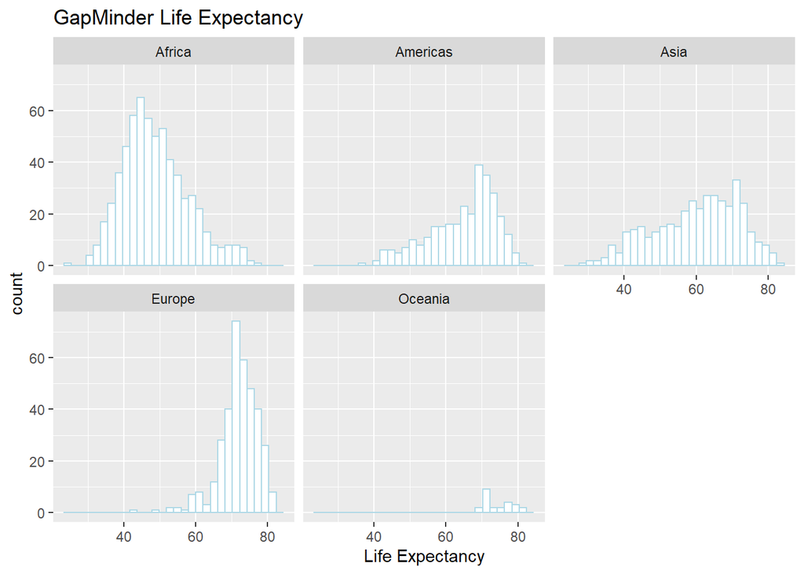

```r
myplot +
  geom_histogram(color = 'lightblue', fill = 'white') +
  facet_wrap(~ continent)
```

The dataset also includes the year that the data was taken in. We can use this as a second grouping, which allows us to make histograms per continent for every year that data was recorded:

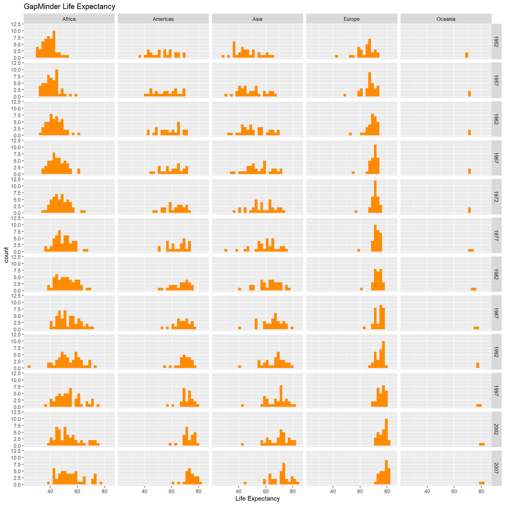

```r
myplot +
  geom_histogram(fill = 'darkorange') +
  facet_grid(year ~ continent)
```